# Problem Set 20

Eric Zhou

2023-01-09

## **Problem 1**

#### **Part a**: Death rate is around 3.406% of the total population overall and applying to Italy returns 87.896 people.

```r
drate <- (79+2835)/(79+2835+2502+80151)
drate
```

```
## [1] 0.03405518
```

```r
drate * (79+2502)
```

```
## [1] 87.89643
```

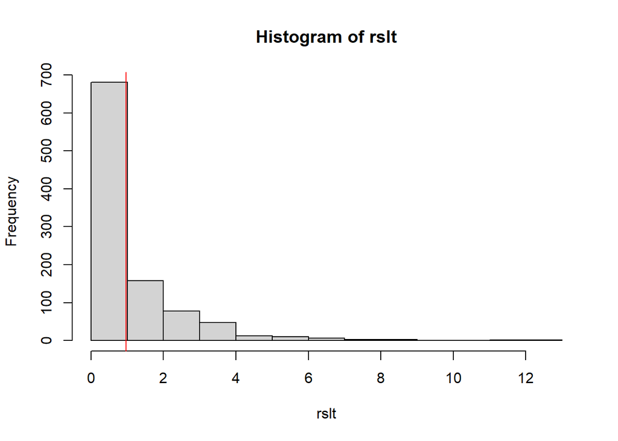

```r
obs <- c(79, 2502, 2835, 80151)
totC <- (2835 + 80151)
totI <- (79 + 2502)
totD <- (79 + 2835)
totR <- (2502 + 80151)
exp <- c(totD * totI, totR * totI, totD * totC, totR * totC) / sum(obs)
obs.ts <- sum((obs-exp)^2/exp)

draw.sample <- function() {
  a <- sample(c(rep('D', totD), rep('R', totR)))
  china <- a[1:totC]
  italy <- a[(totC + 1):sum(obs)]
  return (c(sum(italy=="D"), sum(italy=="R"), sum(china=="D"), sum(china=="R")))
}

nsims <- 1000
rslt <- c()
for (i in 1:nsims){
  samp <- draw.sample()
  rslt[i] <- sum((samp - exp)^2/exp)
}

hist(rslt)
abline(v=obs.ts, col="red")
```

```r
sum(rslt>obs.ts)/length(rslt)
```

```
## [1] 0.32
```

## **Problem 2**

#### **Part a**: For exact numbers, we would require 3 more values so that the rest can be filled in.

#### **Part b**: That there is an independent relationship between grade level and dance attendance.

#### **Part c**: Less than 88% of simulations. Not extreme enough to reject so we fail to reject based on my random numbers.

```r
obs <- c(14, 11, 20, 14, 16, 12, 20, 20)
tots <- c(25, 34, 28, 40)
totG <- 70
totN <- 57
exp <- c(tots[1] * totG, tots[1] * totN, tots[2] * totG, tots[2] * totN, tots[3] * totG, tots[3] * totN, tots[4] * totG, tots[4] * totN) / sum(tots)
obs.ts <- sum((obs-exp)^2/exp)
obs.ts
```

```
## [1] 0.6665273
```

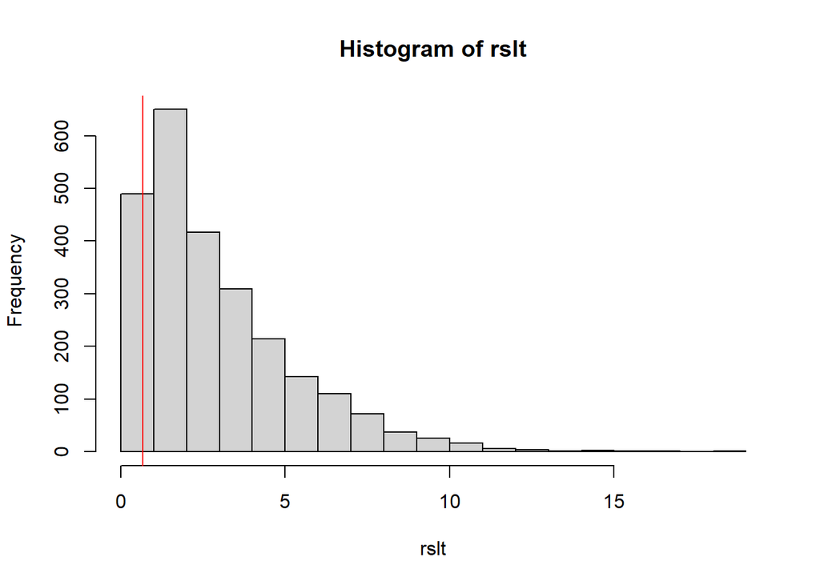

```r
draw.sample <- function() {
  a <- sample(c(rep('G', totG), rep('N', totN)))
  fresh <- a[1:tots[1]]
  soph <- a[(tots[1] + 1):sum(tots[1:2])]
  jun <- a[(sum(tots[1:2]) + 1):sum(tots[1:3])]
  sen <- a[(sum(tots[1:3]) + 1):sum(tots)]
  return (c(sum(fresh=="G"), sum(fresh=="N"), sum(soph=="G"), sum(soph=="N"), sum(jun=="G"), sum(jun=="N"), sum(sen=="G"), sum(sen=="N")))
}

nsims <- 2500
rslt <- c()
for (i in 1:nsims){
  samp <- draw.sample()
  rslt[i] <- sum((samp - exp)^2/exp)
}

hist(rslt)
abline(v=obs.ts, col="red")
```

```r
sum(rslt>obs.ts)/length(rslt)
```

```
## [1] 0.8736
```

## **Problem 3**: The were both almost the exact same, with the test statstic matching the X-squared at 5.8 and the percentage/p-value being 0.2119 vs 0.2146 for the subject and matching 8.13 for X-squared/test statistic and p-value being 0.0858 vs 0.08681.

```r
chisq.test(c(15, 12, 8, 5, 10))
```

```
##
##  Chi-squared test for given probabilities
##
## data:  c(15, 12, 8, 5, 10)
## X-squared = 5.8, df = 4, p-value = 0.2146
```

```r
chisq.test(c(21, 12, 13, 2, 8), p = c(0.51, 0.213, 0.127, 0.05, 0.1))
```

```
##
##  Chi-squared test for given probabilities
##
## data:  c(21, 12, 13, 2, 8)
## X-squared = 8.1334, df = 4, p-value = 0.08681
```

```r
chisq.test(data.frame(c(14, 20, 16, 20), c(11, 14, 12, 20)))
```

```
##
##  Pearson's Chi-squared test
##
## data:  data.frame(c(14, 20, 16, 20), c(11, 14, 12, 20))
## X-squared = 0.66653, df = 3, p-value = 0.881
```